# Texas Housing Sales

# Background

## Purpose

This is a study of housing sales in Texas cities, with a spotlight on the city of Houston. We will have graphs of time trends and run a linear regression model.

## Quick look at the dataset

Dataset from `ggplot2` package

**Variables:**

- **city:** Name of MLS area
- **year, month, date:** year and month, and date expressed as continuous year variable
- **sales:** Number of sales
- **volume:** Total value of sales
- **median:** Median sale price
- **listings:** Total active listings
- **inventory:** “Months inventory”, amount of time it would take to sell all current listings at current pace of sales

Here are the first 20 rows of the spotlight city:

```r
spotcity <- subset(txhousing, txhousing$city==params$spotlight)
knitr::kable(head(spotcity, n=20), align='c')
```

| city | year | month | sales | volume | median | listings | inventory | date |
| --- | --- | --- | --- | --- | --- | --- | --- | --- |
| Houston | 2000 | 1 | 2653 | 381805283 | 102500 | 16768 | 3.9 | 2000 |
| Houston | 2000 | 2 | 3687 | 536456803 | 110300 | 16933 | 3.9 | 2000 |
| Houston | 2000 | 3 | 4733 | 709112659 | 109500 | 17058 | 3.9 | 2000 |
| Houston | 2000 | 4 | 4364 | 649712779 | 110800 | 17716 | 4.1 | 2000 |
| Houston | 2000 | 5 | 5215 | 809459231 | 112700 | 18461 | 4.2 | 2000 |
| Houston | 2000 | 6 | 5655 | 887396592 | 117900 | 18959 | 4.3 | 2000 |
| Houston | 2000 | 7 | 5009 | 770284031 | 118300 | 19391 | 4.4 | 2000 |
| Houston | 2000 | 8 | 5134 | 800032008 | 114600 | 19534 | 4.5 | 2001 |
| Houston | 2000 | 9 | 4262 | 671716256 | 115900 | 19558 | 4.5 | 2001 |
| Houston | 2000 | 10 | 4068 | 621419904 | 112400 | 19752 | 4.5 | 2001 |
| Houston | 2000 | 11 | 3729 | 571270375 | 115200 | 19190 | 4.4 | 2001 |
| Houston | 2000 | 12 | 3950 | 632500396 | 119300 | 18296 | 4.2 | 2001 |
| Houston | 2001 | 1 | 2789 | 412051003 | 111900 | 19097 | 4.4 | 2001 |
| Houston | 2001 | 2 | 3495 | 538463336 | 114400 | 19628 | 4.5 | 2001 |
| Houston | 2001 | 3 | 4689 | 739260418 | 116300 | 20487 | 4.7 | 2001 |
| Houston | 2001 | 4 | 4697 | 749626772 | 122300 | 21307 | 4.9 | 2001 |
| Houston | 2001 | 5 | 5435 | 856531025 | 122500 | 21713 | 4.9 | 2001 |
| Houston | 2001 | 6 | 5501 | 909778437 | 127500 | 21895 | 5.0 | 2001 |
| Houston | 2001 | 7 | 5424 | 903061633 | 127500 | 21791 | 4.9 | 2002 |
| Houston | 2001 | 8 | 5544 | 883998928 | 124200 | 21871 | 4.9 | 2002 |

```r
txhousing$month <- factor(txhousing$month, labels=c("Jan", "Feb", "Mar",
                                                    "Apr", "May", "Jun",
                                                    "Jul", "Aug", "Sep",
                                                    "Oct", "Nov", "Dec"))
```

# Plots

## Time series of Sales By City, Spotlight on Houston

Sales appear to be rising through 2006, then slow until 2010, and then rise again.

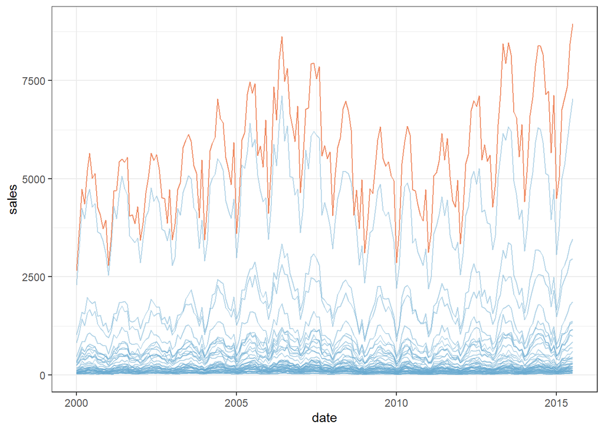

```r
ggplot(txhousing, aes(x=date, y=sales, group=city)) +
  geom_line(color=palette[2], alpha=.5) +
  geom_line(data=spotcity, color=palette[1])
```

## Seasonal trends

We detect seasonal trends in the time series plot, so let’s aggregate across months (by city), to examine sales by month.

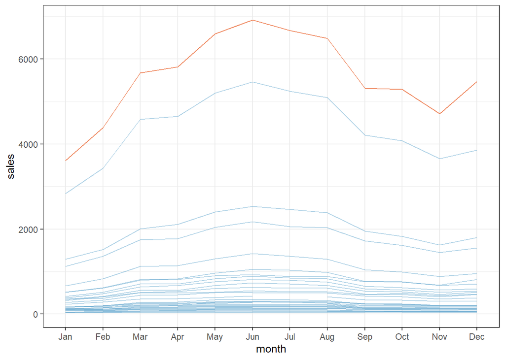

```r
ggplot(by_month, aes(x=month, y=sales, group=city)) +
  geom_line(color=palette[2], alpha=.5) +
  geom_line(data=filter(by_month, city==params$spotlight), color=palette[1])
```

## Removing city effects from seasonal effects

Large differences in the scale of sales make the seasonal effects difficult to see in some plots. Let’s remove the city effect from the monthly aggregates by dividing sales by the mean of sales for that city.

Then, we replot the mean of the rescaled sales by month and city.

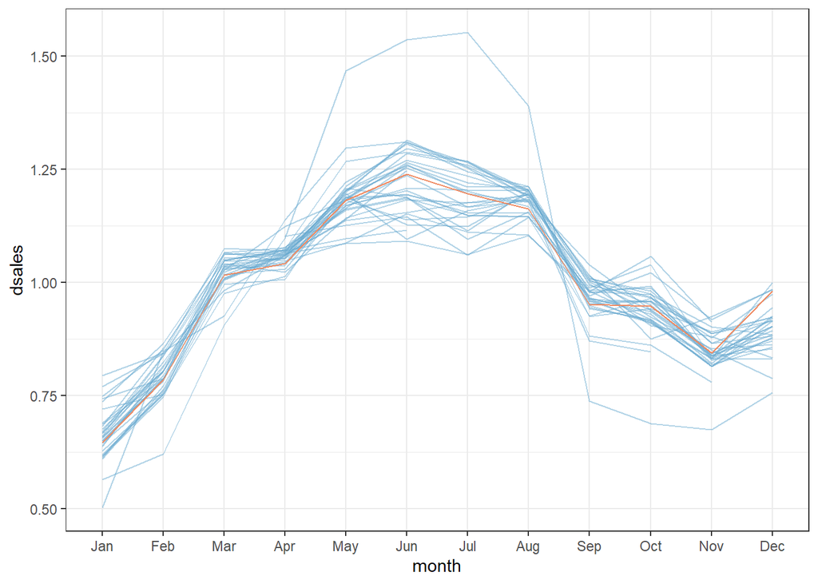

```r
by_month$mean_city_sales <- rep(tapply(by_month$sales, INDEX=by_month$city, mean, na.rm=TRUE), each=12)
by_month$dsales <- by_month$sales/by_month$mean_city_sales

ggplot(by_month, aes(x=month, y=dsales, group=city)) +
  geom_line(color=palette[2], alpha=.5) +
  geom_line(data=filter(by_month, city==params$spotlight), color=palette[1])
```

# Statistical Model

## Regression models

Sales is very skewed so transforming to log for linear regression

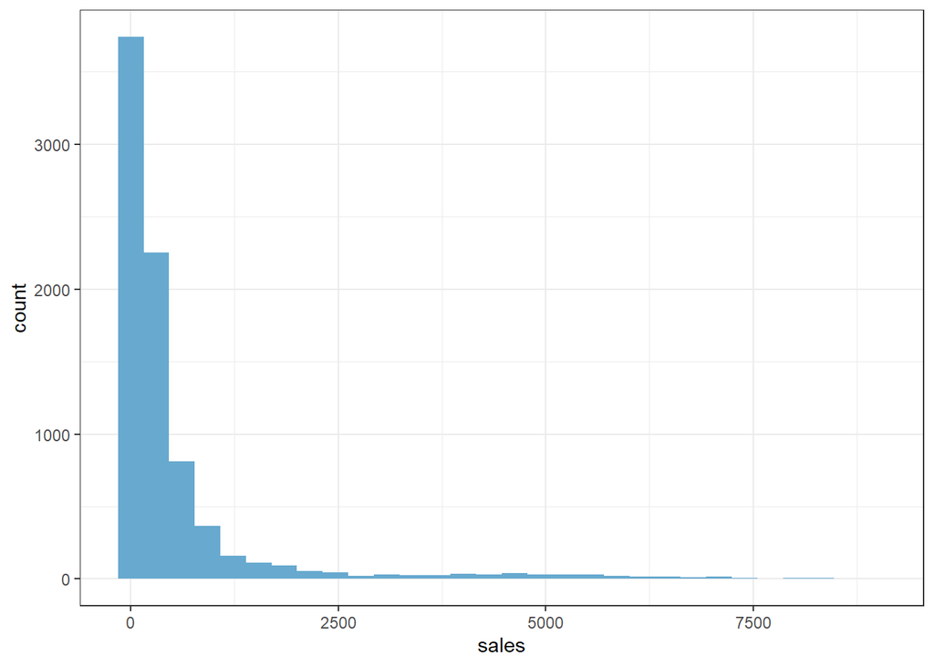

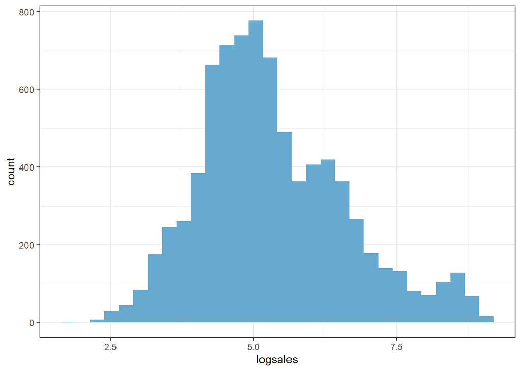

```r
txhousing$logsales <- log(txhousing$sales)
# layout(matrix(c(1,2), nrow=1))
# hist(txhousing$sales)
# hist(txhousing$logsales)
# layout(1)
ggplot(txhousing, aes(x=sales)) + geom_histogram(fill=palette[2])
ggplot(txhousing, aes(x=logsales)) + geom_histogram(fill=palette[2])
```

## Model

Model is $log(sales) = city + year + month + median + \epsilon$, where $city$ and $month$ are factors and $year$ and $median$ are continuous predictors.

Here are the coefficients, not including the city effects (too many):

```r
m <- lm(logsales ~ city + I(year-2000) + month + median , data=txhousing)

mycoefs <- tidy(m, conf.int=TRUE)
mycoefs$term[mycoefs$term==("I(year - 2000)")] <- "year"

coefs_small <- filter(mycoefs, !grepl("city", term))

knitr::kable(coefs_small)
```

| term | estimate | std.error | statistic | p.value | conf.low | conf.high |
| --- | --- | --- | --- | --- | --- | --- |
| (Intercept) | 4.3103 | 0.0209 | 205.9558 | 0.0000 | 4.2692 | 4.3513 |
| year | 0.0005 | 0.0009 | 0.5885 | 0.5562 | -0.0012 | 0.0023 |
| monthFeb | 0.1678 | 0.0117 | 14.3917 | 0.0000 | 0.1449 | 0.1906 |
| monthMar | 0.4129 | 0.0117 | 35.3844 | 0.0000 | 0.3900 | 0.4357 |
| monthApr | 0.4452 | 0.0117 | 38.0648 | 0.0000 | 0.4223 | 0.4682 |
| monthMay | 0.5429 | 0.0118 | 46.2046 | 0.0000 | 0.5199 | 0.5659 |
| monthJun | 0.5680 | 0.0119 | 47.8074 | 0.0000 | 0.5447 | 0.5913 |
| monthJul | 0.5282 | 0.0119 | 44.4569 | 0.0000 | 0.5049 | 0.5515 |
| monthAug | 0.5477 | 0.0120 | 45.6117 | 0.0000 | 0.5242 | 0.5712 |
| monthSep | 0.3491 | 0.0120 | 29.2006 | 0.0000 | 0.3256 | 0.3725 |
| monthOct | 0.3213 | 0.0119 | 26.9545 | 0.0000 | 0.2979 | 0.3447 |
| monthNov | 0.2147 | 0.0119 | 17.9906 | 0.0000 | 0.1913 | 0.2381 |
| monthDec | 0.2695 | 0.0120 | 22.5504 | 0.0000 | 0.2461 | 0.2930 |
| median | 0.0000 | 0.0000 | 17.5667 | 0.0000 | 0.0000 | 0.0000 |

## Diagnostic plots

### Residuals vs. fitted

Linearity assumption seems to be ok, but maybe not homoskedasticity assumption.

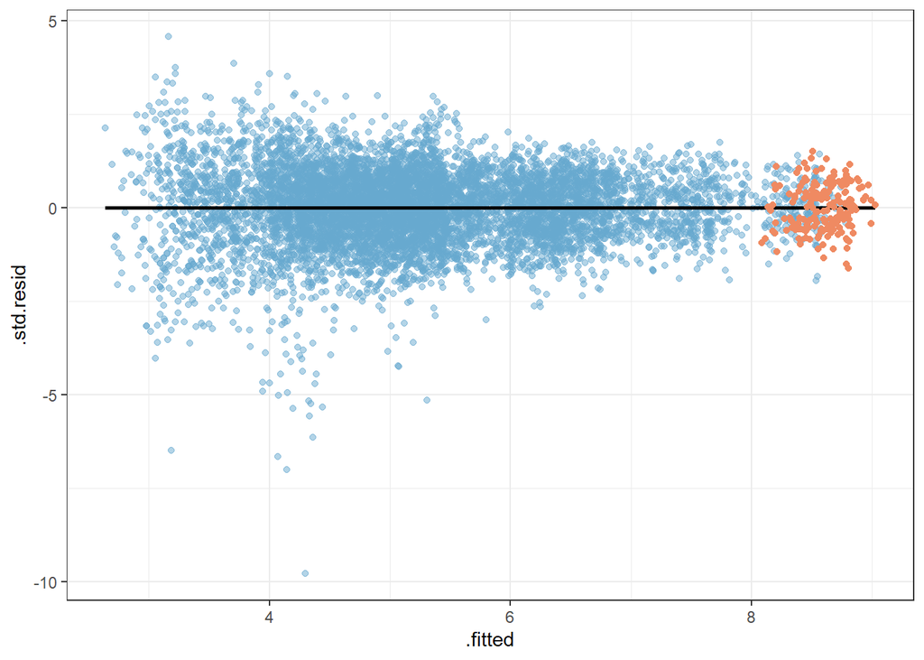

```r
# use broom::augment() to make a dataset of regression diagnostics
diagnostics <- augment(m)
# add the city variable so we can spotlight
diagnostics$city <- txhousing$city[as.numeric(diagnostics$`.rownames`)]

# residuals vs fitted plot
ggplot(diagnostics, aes(x=.fitted, y=.std.resid)) +
  geom_point(color=palette[2], alpha=.5) +
  geom_smooth(color="black")+
  geom_point(data=subset(diagnostics, diagnostics$city==params$spotlight), color=palette[1])
```

### q-q plot of residuals

Some departures from normality in tails, but we have a very large sample size, so maybe not a big deal.

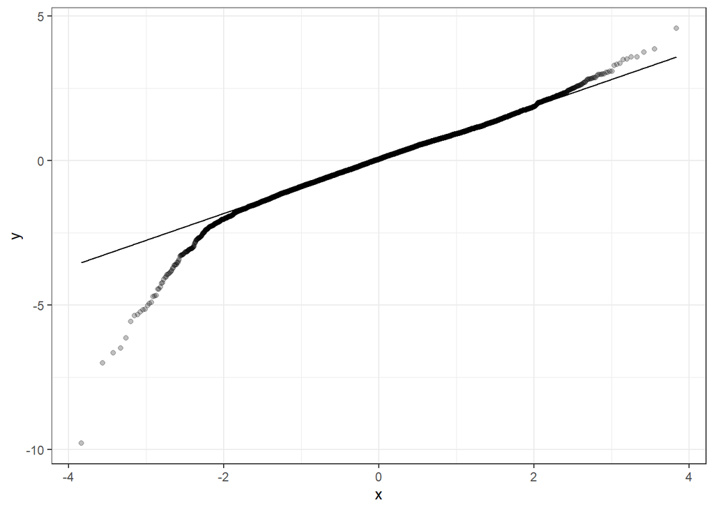

```r
ggplot(diagnostics, aes(sample=.std.resid)) +
  geom_qq(alpha=.25) +
  geom_qq_line()
```

### Influence plot

Residuals vs leverage, sized by Cook’s distance.

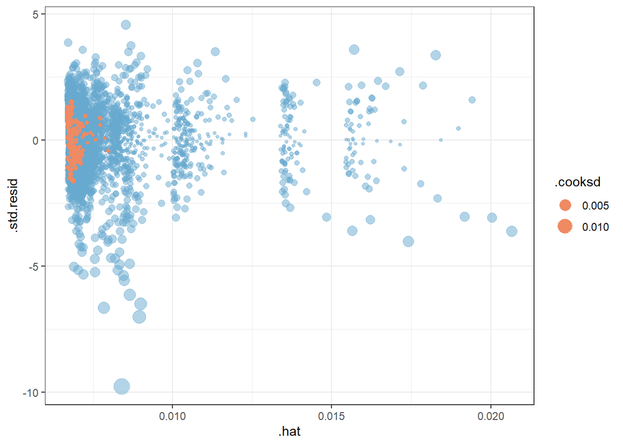

```r
ggplot(diagnostics, aes(x=.hat, y=.std.resid, size=.cooksd)) +
  geom_point(color=palette[2], alpha=.5) +
  geom_point(data=subset(diagnostics, diagnostics$city==params$spotlight), color=palette[1])
```